# Week 5 Class Activity

## Load Necessary Libraries

```r
library(ggplot2) # for graphing
library(viridis) # color palettes
library(MetBrewer) # color palettes
library(tidyverse) # for data cleaning
library(psych) # for scales
```

## Test-Retest Reliability: Ex. 1 Correlation

```r
Time1 <- c(54, 67, 67, 83, 87, 89, 84, 90, 98, 65)
Time2 <- c(56, 77, 87, 89, 89, 90, 87, 92, 99, 76)
test.data <- data.frame(Time1, Time2)

cor(test.data$Time1, test.data$Time2)
```

```
## [1] 0.9005792
```

### Test-Retest Reliability: Graph

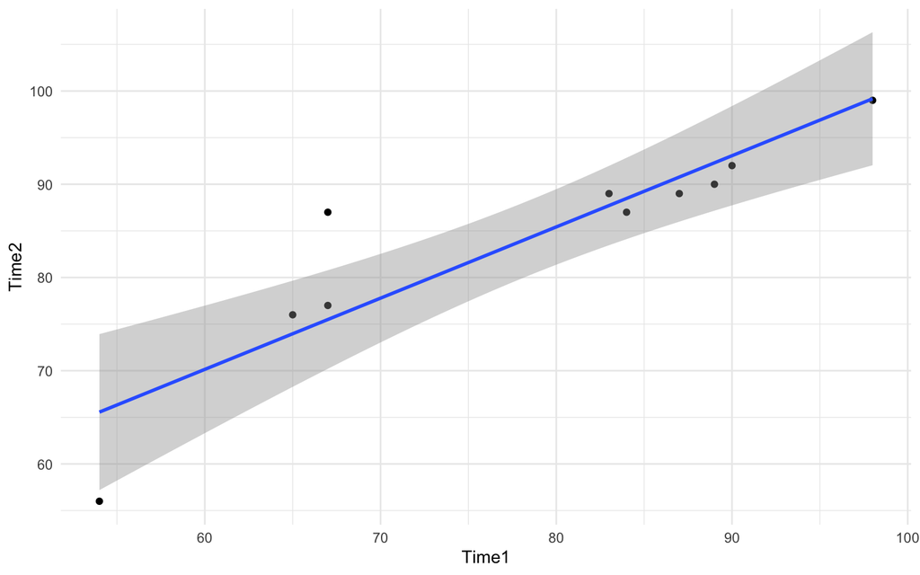

```r
ggplot(test.data, aes(Time1, Time2)) +
  geom_point() +
  geom_smooth(method = "lm") +
  theme_minimal()
```

## Test-Retest Reliability: Ex. 2 Correlation

```r
FormA <- c(4, 5, 3, 6, 7, 5, 6, 4, 3, 3)
FormB <- c(5, 6, 5, 6, 7, 6, 7, 8, 7, 7)
form.data <- data.frame(FormA, FormB)

cor(form.data$FormA, form.data$FormB)
```

```
## [1] 0.1286979
```

### Test-Retest Reliability: Graph

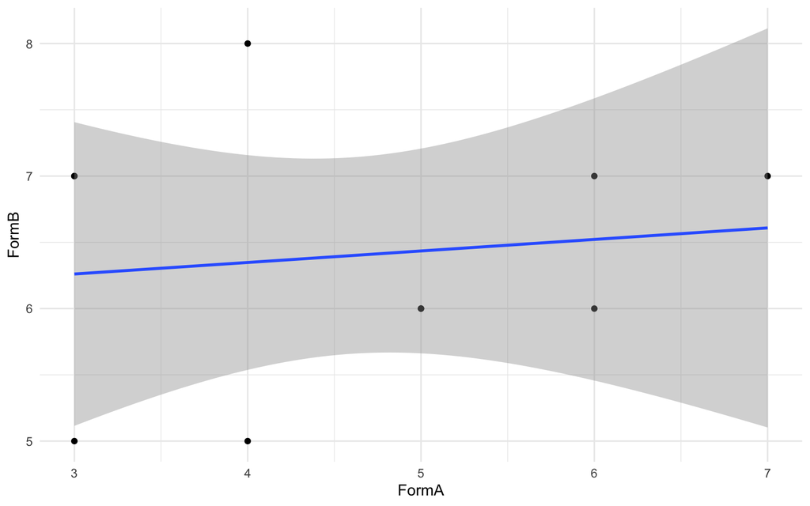

```r
ggplot(form.data, aes(FormA, FormB)) +
  geom_point() +
  geom_smooth(method = "lm") +
  theme_minimal()
```

## Chronbach’s Alpha

### Load in Dataset

```r
mydata <- read.csv("../Data/ch8ds1.csv")
head(mydata)
```

```
##   Item1 Item2 Item3 Item4 Item5
## 1     3     5     1     4     1
## 2     4     4     3     5     3
## 3     3     4     4     4     4
## 4     3     3     5     2     1
## 5     3     4     5     4     3
## 6     4     5     5     3     2
```

### Compute Alpha Reliability

```r
psych::alpha(mydata)$total
```

```
## Some items ( Item3 Item5 ) were negatively correlated with the total scale and
## probably should be reversed.
## To do this, run the function again with the 'check.keys=TRUE' option
```

```
##  raw_alpha std.alpha   G6(smc)  average_r       S/N       ase mean        sd
##  0.2387153 0.2336256 0.4265535 0.05746544 0.3048453 0.3712161 3.44 0.5059644
##    median_r
##  0.07965954
```

```r
psych::alpha(mydata, check.keys=TRUE)$total
```

```
##  raw_alpha std.alpha   G6(smc) average_r       S/N       ase mean        sd
##  0.4364525 0.4395844 0.5427571 0.1356046 0.7843901 0.2611147 3.24 0.5641119
##   median_r
##  0.1994811
```

## Let’s Create a Scale!

We’ll work together to make a scale on: happiness

Let’s brainstorm some potential Questions/Statements. For the questions you come up with, make sure they are framed such that they can use the response scale 1-7, from strongly disagree to strongly agree.

1 - Strongly disagree 2 - Disagree 3 - Somewhat disagree 4 - Neither disagree/agree 5 - Somewhat agree 6 - Agree 7 - Strongly agree

*For the below statements, rate how much you disagree/agree*

1. I am satisfied with my life
2. I have a hard time getting up in the morning*
3. I laugh every day
4. I feel satisfied at the end of the day
5. I am productive throughout my day
6. I believe happiness is a choice
7. Happiness can be a bad thing*
8. I am mentally healthy
9. I find myself genuinely smiling a lot
10. I am a morning person
11. I am stressed easily*
12. I am surrounded by people I love.
13. I feel lonely all the time.
14. I spend my time doing things I enjoy.
15. I feel hopeless*
16. I am content with my job
17. I have a strong family unit
18. I love music
19. I make time for self-care
20. I like to eat sweet foods

```r
classdata <- read.csv("https://raw.githubusercontent.com/AmandaDPerez/DVCPsych214/main/ClassSurvey.csv")

classdata <-  classdata[,2:21]
head(classdata)
```

```
##   Q1 Q2 Q3 Q4 Q5 Q6 Q7 Q8 Q9 Q10 Q11 Q12 Q13 Q14 Q15 Q16 Q17 Q18 Q19 Q20
## 1  5  6  4  6  5  7  4  5  4   2   3   5   3   5   1   7   5   5   4   6
## 2  6  4  6  6  4  5  3  6  6   7   5   6   2   7   2   4   7   7   5   5
## 3  2  6  5  2  2  4  2  1  5   2   1   6   6   3   7   4   5   6   3   7
## 4  7  4  7  4  2  3  1  3  6   1   7   7   1   5   1   5   7   5   7   7
## 5  6  1  6  3  3  7  6  4  3   5   7   3   3   3   5   5   7   7   4   3
## 6  5  4  5  5  5  6  4  5  4   1   5   4   2   6   2   4   5   6   5   4
```

### Checking Alpha

```r
psych::alpha(classdata, check.keys=TRUE)$total
```

```
##  raw_alpha std.alpha   G6(smc) average_r      S/N        ase     mean        sd
##  0.8387334 0.8485577 0.9589412 0.2188469 5.603175 0.04495438 4.127778 0.7898799
##   median_r
##  0.2121938
```

### Checking Factor Loadings

We can get rid of lower performing items to improve our alpha. However, sometimes getting rid of items can *harm* alpha. This is because the more scale items a scale has, the greater reliability it tends to have. However, item reduction is very important when creating a new scale. When creating a new scale, you may start with 60+ scale items and use item reduction to pick the best 15 items.

Next, we can get our factor loadings and see which ones make the cutoff.

```r
class.scale.loadings <- fa(classdata, nfactors = 1, rotate = "oblimin", fm = "minres")
print(class.scale.loadings$loadings, cutoff = 0.5)
```

```
##
## Loadings:
##     MR1
## Q1   0.684
## Q2
## Q3
## Q4   0.679
## Q5
## Q6
## Q7  -0.569
## Q8   0.591
## Q9   0.631
## Q10
## Q11
## Q12  0.515
## Q13 -0.805
## Q14  0.651
## Q15 -0.626
## Q16  0.640
## Q17
## Q18
## Q19
## Q20
##
##                  MR1
## SS loadings    5.150
## Proportion Var 0.257
```

We can also see visually what it looks like.

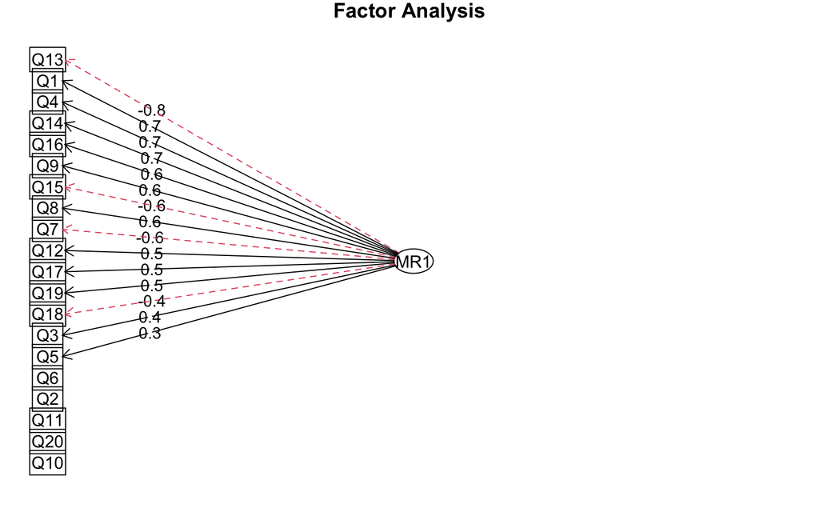

```r
fa.diagram(class.scale.loadings)
```

```r
# No strict rule but generally .4 is a good cut off for a factor loading.
```

Final step is to make a note of what our final items are.

### Scoring our Final Items

Now that we know which items to include, we want to score our scale and get the alpha. By scoring the scale, every participant (y’all) will get one final summary score that represents how you responded to the scale.

First, we have to make a list of our variable names. If we have any reverse-score items we need to add a “-” to the name.

```r
keys.list <- list(happiness=c( "Q1", "Q4", "-Q7", "Q8", "Q9",
                               "Q12", "-Q13", "Q14", "-Q15", "Q16"
  ))
```

Next, we score the items and see the alpha.

```r
scores <- scoreItems(keys.list, classdata, min = 1, max = 7)

summary(scores, short = F)
```

```
## Call: scoreItems(keys = keys.list, items = classdata, min = 1, max = 7)
##
## Scale intercorrelations corrected for attenuation
##  raw correlations below the diagonal, (unstandardized) alpha on the diagonal
##  corrected correlations above the diagonal:
##           happiness
## happiness      0.88
```

```r
classdata$HAPPY <- scoreItems(keys.list, classdata, min=1,max=7)$score[,1]
```

Let’s look at the individual scores.

```r
classdata$HAPPY
```

```
##  [1] 5.3 5.8 3.2 5.8 3.7 4.9 4.2 4.8 5.8 3.6 3.9 5.0 5.8 3.8 1.5 4.4 4.4 4.8 4.3
## [20] 4.8 2.9 4.7 4.5 5.7 2.4 4.3 5.5
```

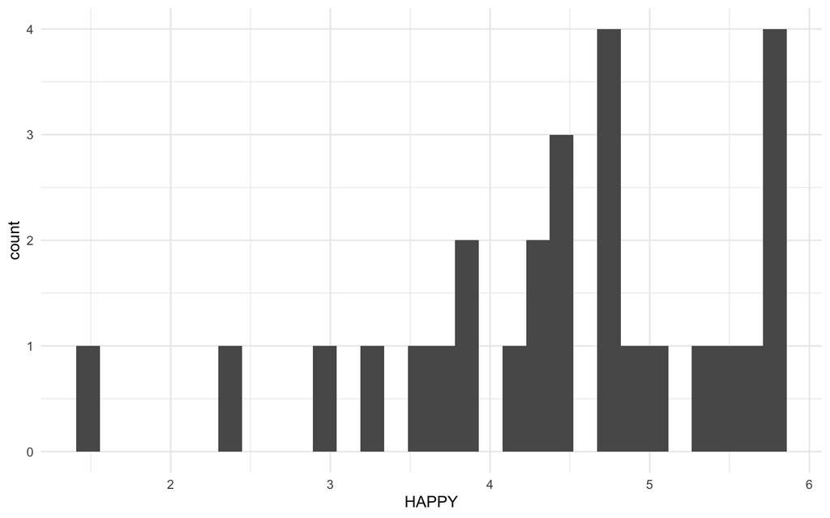

```r
ggplot(classdata, aes(HAPPY)) +
  geom_histogram() +
  theme_minimal()
```

### Our Final Scale Items!

1 - Strongly disagree 2 - Disagree 3 - Somewhat disagree 4 - Neither disagree/agree 5 - Somewhat agree 6 - Agree 7 - Strongly agree

For the below statements, rate how much you disagree/agree

1. I am satisfied with my life
2. I feel satisfied at the end of the day
3. Happiness can be a bad thing (REVERSE)
4. I am mentally healthy
5. I find myself genuinely smiling a lot
6. I am surrounded by people I love
7. I feel lonely all the time (REVERSE)
8. I spend my time doing things I enjoy
9. I feel hopeless (REVERSE)
10. I am content with my job